# Correlation matrix

```r
suppressPackageStartupMessages({

library(ArchR)
library(tidyverse)
library(SingleCellExperiment)
library(zellkonverter)
library(dtwclust)
})
```

In order to get gene regulatory links, one can compute a simple correlation between accessible peaks and gene expression, in order to find peaks whose activity is highly correlated with expression of a certain gene. These are potential enhancers of a gene. Since single cell data is very sparse, the common way to compute correlatiosn is by aggregating accessibility and gene expression data across cell aggregates. In ArchR this is done by sampling 500 cells from the entire dataset and finding the 50 nearest neighbors of these cells. These cell aggregates therefore reprsent groups of similar cells and can be used to compute correlations.

Based on these putative peak-to-gene links, it is possible to compute gene activity scores. If these scores recapitulate gene expression well, this is a validation of the links. In the following you will find a function to compute gene activity scores from peak-to-gene links. Using Python the obtained gene activity scores were correlated with gene expression and further examined. Here, we focus on computing the gene activity scores.

Furthermore, since peaks which are farther away from a gene on the genome are less likely to regulate this gene, it is common to use distance weigths to penalize peaks which are highly correlated, but distant. However, I observed that using distance weigths decreases the correlation with gene expression, with less steep decay rates resulting in better gene activity scores. This shows that the distance weights lead to a lot of zero values when multiplied with the correlation values.

Yet another approach would be to use only peaks, which are within +/- 100kb of the TSS of a gene, thereby, removing any peaks which are far away.

# Add Peak2Gene Links

Using ArchR I computed the peak-to-gene links on the entire chromosome. Then, I proceeded with positive links with a false discovery rate below 1e-04 and correlation above 0.2.

```
proj <- loadArchRProject("12_Ricards_peaks_ChromVar/")

proj <- addPeak2GeneLinks(  ArchRProj = proj,
  reducedDims  = "atac_LSI_100000",
  useMatrix = "GeneExpressionMatrix",
  maxDist = 400000000,
  verbose = FALSE
  )

p2g <- getPeak2GeneLinks(
  ArchRProj = proj,
  corCutOff = -1,
  resolution = 1,
  FDRCutOff = 1e-04,
  varCutOffATAC = .25,
  varCutOffRNA = .25,
  returnLoops = FALSE
)
```

```r
# save the original p2g links dataframe, inclduing the metadata
p2g_original <- readRDS("p2g_links_archr/p2g_links_with_metadata")

# save the dataframe only containing positive correlations
#saveRDS(p2g, "p2g_links_archr/pos_peak2gene_links_df.rds")
p2g <- readRDS("p2g_links_archr/pos_peak2gene_links_df.rds")


print(paste0("Using ArchR we get ", length(unique(p2g$chr_idx)), " peaks which are positively linked to genes"))
## [1] "Using ArchR we get 135283 peaks which are positively linked to genes"
```

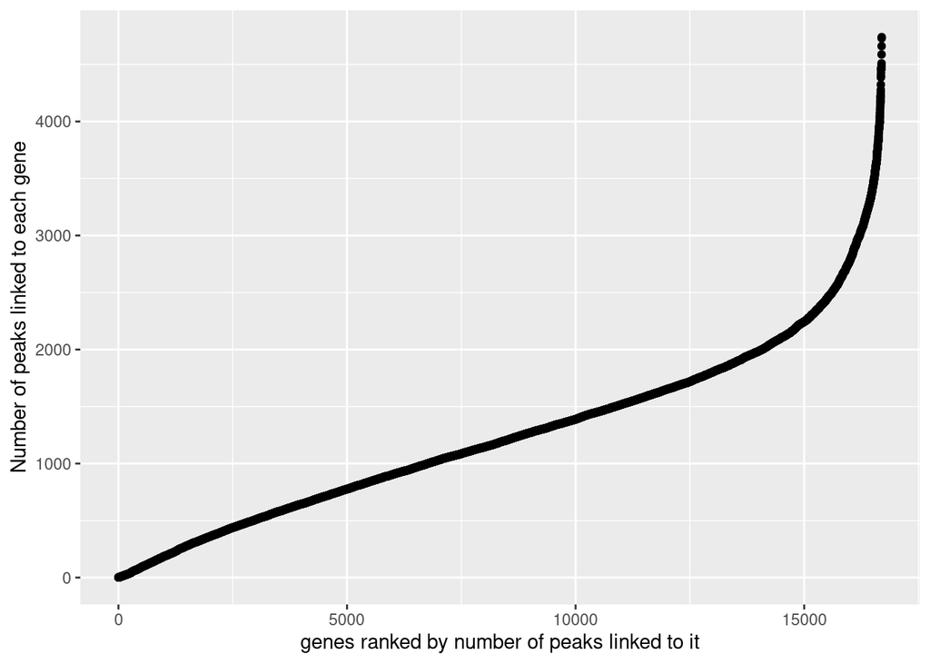

```r
p2g %>% group_by(gene) %>%
  summarise(peak_count = n()) %>% # count number of peaks per gene
  arrange((peak_count)) %>% # sort by deacreasing number of genes
  mutate(rank = seq_along(peak_count)) %>%
  ggplot() +
  geom_point(aes(x = rank, y = peak_count)) +
  labs(y = "Number of peaks linked to each gene",
       x = "genes ranked by number of peaks linked to it")
```

# Function p2g link dataframe to matrix

ArchR returns a dataframe of peak-to-gene links and corresponding annotations. From this dataframe we first need to create a peak-to-gene link matrix.

```r
metadata_p2g_atac <- as.data.frame(metadata(p2g_original)[[1]])
metadata_p2g_rna <- as.data.frame(metadata(p2g_original)[[2]])


p2g_matrix_from_df <- function(p2g, metadata_p2g_rna, metadata_p2g_atac){
  # add chrosome identifiers to p2g dataframe
  metadata_p2g_atac <- metadata_p2g_atac %>%  rownames_to_column("idxATAC") %>%
  group_by(seqnames) %>%
  # create idx per chromosome
  mutate(idx = seq_along(seqnames)) %>% ungroup() %>%
  # create chr & index combination column, will be needed, since this is how we name peak matrix
  tidyr::unite(chr_idx, seqnames, idx, remove = FALSE, sep = "_")


  #fitler to get only the peaks which we have in the p2g links dataframe
  atac_chr_idx <- metadata_p2g_atac %>% filter(idxATAC %in% p2g$idxATAC) %>%
    select(idxATAC, chr_idx)

  atac_chr_idx$idxATAC <- as.integer(atac_chr_idx$idxATAC)

  # now we can merge this with the p2g dataframe based on the idxATAC column
  p2g_idx <- inner_join(atac_chr_idx, p2g, by = "idxATAC",copy = TRUE)

  # add gene names to p2g dataframe
  # get gene names
  rna_idx <- metadata_p2g_rna %>% rownames_to_column("idxRNA") %>%
    group_by(seqnames) %>%
    mutate(idx = seq_along(seqnames)) %>% ungroup() %>%
    tidyr::unite(chr_idx_rna, seqnames, idx, remove = FALSE, sep = "_") %>%
    filter(idxRNA %in% p2g_idx$idxRNA) %>%
    select(idxRNA, name, chr_idx_rna) %>% rename("gene" = name)

  rna_idx$idxRNA <- as.integer(rna_idx$idxRNA)

  # combine this with the p2g dataframe
  p2g_idx <- left_join(rna_idx, p2g_idx, by = "idxRNA", copy = TRUE )

  # create p2g link matrix
  # create column and row indices for the unique peak and rna indices
  p2g_idx$ColIndex <- match(p2g_idx$chr_idx, unique(p2g_idx$chr_idx))
  p2g_idx$RowIndex <- match(p2g_idx$gene, unique(p2g_idx$gene))

  # create a sparse matrix with the correlation values
  p2g_mat <- sparseMatrix(i = p2g_idx$RowIndex,
                          j = p2g_idx$ColIndex,
                          x = p2g_idx$Correlation,
                          dims = c(length(unique(p2g_idx$gene)),
                                   length(unique(p2g_idx$chr_idx))),
                          dimnames = list(unique(p2g_idx$gene),
                                          unique(p2g_idx$chr_idx)))

  print(paste0("The sparse matrix of correlations has dimensions: ", dim(p2g_mat)[[1]], " genes and ", dim(p2g_mat)[[2]], " peaks."))
  print(paste0("Minimum value: ", min(p2g_mat)))
  print(paste0("The maximum value: ", max(p2g_mat)))

  return(list(p2g_mat, p2g_idx))
}
```

**Creating p2g matrix for all links and for only positive links**

```
# only positive p2g_links_mat
p2g_mat_df <- p2g_matrix_from_df(p2g, metadata_p2g_rna, metadata_p2g_atac)

p2g_mat <- p2g_mat_df[[1]]
p2g_df <- p2g_mat_df[[2]]

#save dataframe
saveRDS(p2g_df, "p2g_links_archr/pos_peak2gene_links_df.rds")

#save only positive correlations in p2g links matrix
sce <- SingleCellExperiment(list("positive_p2g_links"=p2g_mat),
                           rowData = as.data.frame(rownames(p2g_mat)),
                           colData = as.data.frame(colnames(p2g_mat)))

writeH5AD(sce, "/omics/groups/OE0533/internal/katharina/scDoRI/gastrulation_data/p2g_links_archr/positive_p2g_link_matrix.h5ad", X_name = "positive_p2g_links")






# all p2g_links
all_p2g <- p2g_matrix_from_df(as.data.frame(p2g_original),
                                  metadata_p2g_rna, metadata_p2g_atac )

p2g_mat_all <- all_p2g[[1]]
p2g_df_all <- all_p2g[[2]]

# save dataframe
saveRDS(p2g_df_all, "p2g_links_archr/all_peak2gene_links_df.rds")

#save all p2g links as a matrix
sce <- SingleCellExperiment(list("p2g_links"=p2g_mat_all),
                           rowData = as.data.frame(rownames(p2g_mat_all)),
                           colData = as.data.frame(colnames(p2g_mat_all)))

writeH5AD(sce, "/omics/groups/OE0533/internal/katharina/scDoRI/gastrulation_data/p2g_link_matrix.h5ad", X_name = "p2g_links")
```

# Use positive correlation values

Since using negative and positive correlation values did not yield very nice results, here we will only use positive correlation values. The negative values are quite hard to interpret in addition to yielding worse gene activity scores.

```r
# read in positive peak to gene matrix
pos_p2g_mat <- readH5AD("p2g_links_archr/positive_p2g_link_matrix.h5ad")
pos_p2g_mat <- assays(pos_p2g_mat)[[1]]
```

# Z-scores

The z-score gives you an idea how far away from the mean a data point is. If all values are rather high, the z-scores will be very similar for all datapoints. If there is one datapoint with a higher value compared to the rest, the z-score will be bigger for this particular datapoint.

First, lets plot the mean correlation values across all genes for each peak. We can see that there are quite a lot of peaks which have high mean correlation (small peak on the right hand side of the larger peak in the figure below), which indicates that they are highly correlated with many genes. This would bias our calculations downstream, since they could overshadow peaks which are actually specific to genes. Computing z-scores we can alleviat this problem.

Another thing to take into consideration is the number of genes I use for the gene activity score computations. I will try to only keep the most highly variable genes, in order to not bias the calculations.

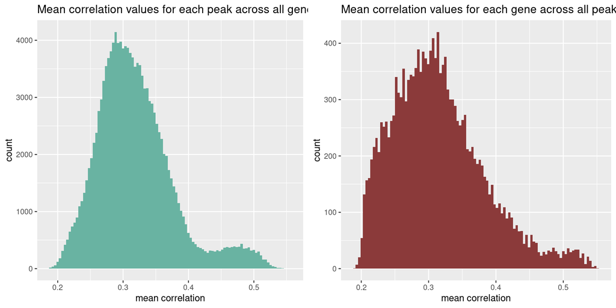

```r
#pos_p2g_mat <- pmax(p2g_mat, 0)
#pos_p2g_mat <- p2g_mat

#pos_p2g_mat[which(pos_p2g_mat < 0)] = 0

p1 <- p2g %>%
  group_by(idxATAC) %>%
  select(idxATAC, Correlation) %>%
  summarize(mean = mean(Correlation)) %>%
  ggplot(aes(x = mean)) +
  geom_histogram(bins = 100, fill="#69b3a2" ) +
  labs(title = "Mean correlation values for each peak across all genes",
       x = "mean correlation")


p2 <- p2g %>%
  group_by(idxRNA) %>%
  select(idxRNA, Correlation) %>%
  summarize(mean = mean(Correlation)) %>%
  ggplot(aes(x = mean)) +
  geom_histogram(bins = 100, fill="indianred4") +
  labs(title = "Mean correlation values for each gene across all peaks",
       x = "mean correlation")

cowplot::plot_grid(p1, p2, ncol = 2)
```

Same plot as above, but only containing highly variable genes:

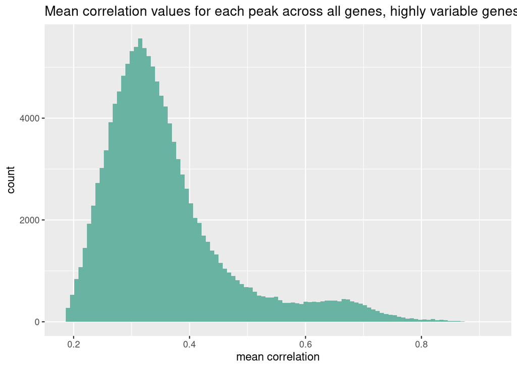

```r
hvg_list <- read.table("jupyter_notebooks/hvg_list", sep = ",")$x

p2g %>%
  filter(gene %in% hvg_list) %>%
  group_by(idxATAC) %>%
  select(idxATAC, Correlation) %>%
  summarize(mean = mean(Correlation)) %>%
  ggplot(aes(x = mean)) +
  geom_histogram(bins = 100, fill="#69b3a2") +
  labs(title = "Mean correlation values for each peak across all genes, highly variable genes",
       x = "mean correlation")
```

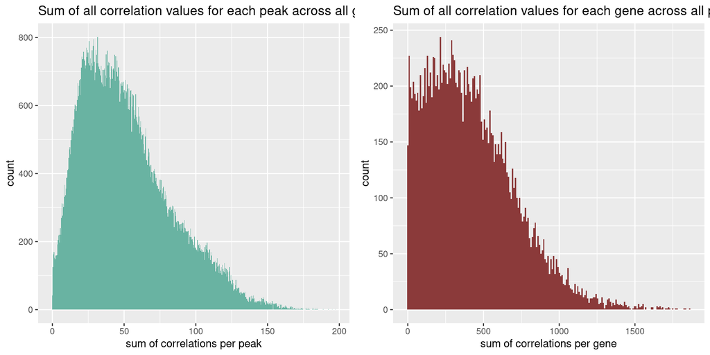

```r
# filter for the most highly variable genes

p1 <- ggplot() + geom_histogram(aes(x = colSums(pos_p2g_mat)), bins = 500, fill="#69b3a2") +
  labs(title = "Sum of all correlation values for each peak across all genes",
       x = "sum of correlations per peak")

print(paste0("There are ", length(which(colSums(pos_p2g_mat) == 0)), " peaks which have no correlation with any gene"))
## [1] "There are 0 peaks which have no correlation with any gene"

p2 <- ggplot() + geom_histogram(aes(x = rowSums(pos_p2g_mat)), bins = 200, fill="indianred4") +
  labs(title = "Sum of all correlation values for each gene across all peaks",
       x = "sum of correlations per gene")
cowplot::plot_grid(p1, p2, ncol = 2)
```

```r
print(paste0("There are ", length(which(rowSums(pos_p2g_mat) == 0)), " genes which have no correlation with any peak"))
## [1] "There are 0 genes which have no correlation with any peak"
```

Now we want to filter for highly variable genes and use only correlations with these genes. Some peaks might get zero correlation with these genes, so we will remove these peaks as well.

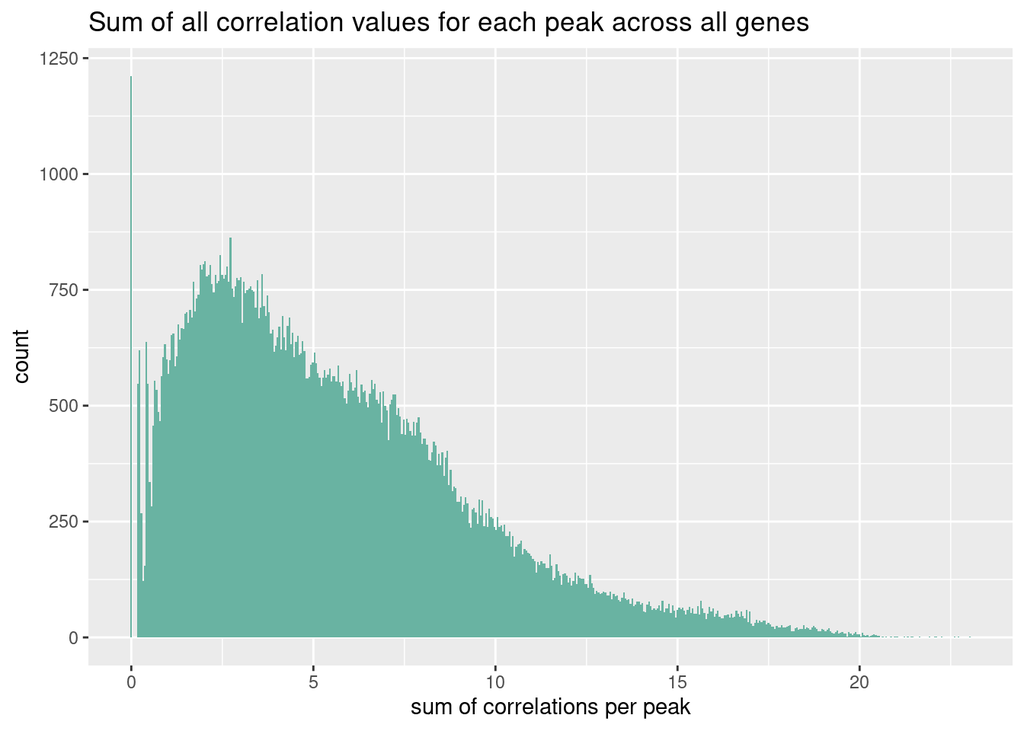

```r
# If we filter for only highly variable genes, we should check whethter
# there are some peaks which are not correlated with any of the remaining
# genes and remove those
hvg_p2g <- pos_p2g_mat[rownames(pos_p2g_mat) %in% hvg_list, ]
hvg_p2g[1:10, 1:5]
## 10 x 5 sparse Matrix of class "dgCMatrix"
##                  chr1_1    chr1_2    chr1_6    chr1_7    chr1_9
## Xkr4          0.4354260 0.6596990 0.8672887 0.8186919 0.5417665
## Rp1           .         .         .         .         .
## Sntg1         .         0.2551951 0.2398727 0.2334835 0.4000295
## 1700034P13Rik 0.3364093 0.4393195 0.5065306 0.5403515 0.3078910
## Sgk3          .         .         .         .         .
## Cpa6          .         .         .         .         .
## Prex2         .         .         .         .         0.2547989
## A830018L16Rik 0.2115539 0.3648232 0.5808419 0.4715983 0.4014615
## Eya1          .         .         .         .         .
## Kcnb2         .         .         .         .         .

print(paste0("Instead of ", dim(pos_p2g_mat)[[1]], " genes, we use only the ",
             length(hvg_list), " most highly variable genes and ", dim(hvg_p2g)[[2]], " peaks."))
## [1] "Instead of 16696 genes, we use only the 1722 most highly variable genes and 135283 peaks."

ggplot() + geom_histogram(aes(x = colSums(hvg_p2g)), bins = 500, fill="#69b3a2") +
  labs(title = "Sum of all correlation values for each peak across all genes",
       x = "sum of correlations per peak")
```

```r
print(paste0("There are ", length(which(colSums(hvg_p2g) == 0)), " peaks which have no correlation with any gene"))
## [1] "There are 1211 peaks which have no correlation with any gene"
print("We will remove these peaks, since they do not contain any information.")
## [1] "We will remove these peaks, since they do not contain any information."

hvg_p2g <- hvg_p2g[, which(colSums(hvg_p2g) != 0)]

print(paste0("Now we are left with ", dim(hvg_p2g)[[2]], " peaks."))
## [1] "Now we are left with 134072 peaks."
```

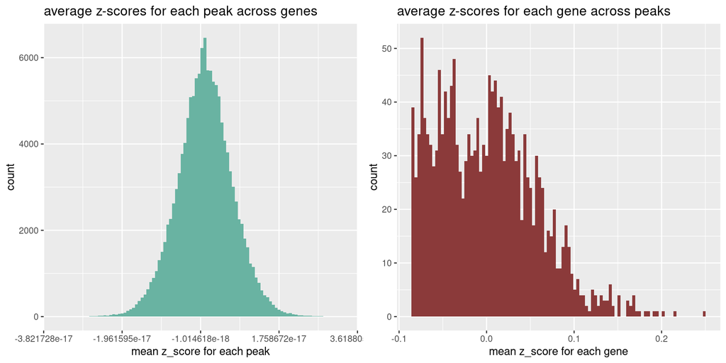

```r
# computes z-scores row-wise -> transpose the matrix and re-transpose after computation
zscore_mat <- t(zscore(t(as.matrix(hvg_p2g))))
print(paste0("The minimum value in the z-score matrix is: ", min(zscore_mat), " the maximum value is ", max(zscore_mat)))
## [1] "The minimum value in the z-score matrix is: -0.18573762054458 the maximum value is 41.2795419810646"
zscore_mat[1:10, 1:5]
##                    chr1_1     chr1_2     chr1_6     chr1_7     chr1_9
## Xkr4          17.69487508 17.4763625 19.4128169 19.1131958 10.1281521
## Rp1           -0.08813156 -0.1058569 -0.1045281 -0.1040552 -0.1249569
## Sntg1         -0.08813156  6.6955735  5.2935331  5.3765298  7.4457316
## 1700034P13Rik 13.65098597 11.6028344 11.2943660 12.5796791  5.7019803
## Sgk3          -0.08813156 -0.1058569 -0.1045281 -0.1040552 -0.1249569
## Cpa6          -0.08813156 -0.1058569 -0.1045281 -0.1040552 -0.1249569
## Prex2         -0.08813156 -0.1058569 -0.1045281 -0.1040552  4.6971950
## A830018L16Rik  8.55182887  9.6173664 12.9666575 10.9658262  7.4728332
## Eya1          -0.08813156 -0.1058569 -0.1045281 -0.1040552 -0.1249569
## Kcnb2         -0.08813156 -0.1058569 -0.1045281 -0.1040552 -0.1249569

p1 <- ggplot() + geom_histogram(aes(x = colMeans(zscore_mat)), bins = 100, fill="#69b3a2") +
  labs(x = "mean z_score for each peak", title = "average z-scores for each peak across genes")

p2 <- ggplot() + geom_histogram(aes(x = rowMeans(zscore_mat)), bins = 100, fill = "indianred4") +
  labs(x = "mean z_score for each gene", title = "average z-scores for each gene across peaks")

cowplot::plot_grid(p1, p2, ncol = 2)
```

```r
# For computing the gene activity score I will again have to set negative values to zero
zscore_mat[which(zscore_mat < 0)] = 0
print(paste0("The minimum value in the z-score matrix after setting negative values to zero is: ", min(zscore_mat), " the maximum value is ", max(zscore_mat)))
## [1] "The minimum value in the z-score matrix after setting negative values to zero is: 0 the maximum value is 41.2795419810646"

#ggplot() + geom_histogram(aes(x = colSums(zscore_mat) / colSums(!!zscore_mat)), bins = 100)
```

Now we will use this z-score matrix to compute our gene activity scores:

```r
proj <- loadArchRProject("12_Ricards_peaks_ChromVar/")
# get peak matrix
peaks <- getMatrixFromProject(proj, useMatrix = "PeakMatrix", binarize = FALSE)
peak_mat <- assays(peaks)[[1]]
peakset <- as_tibble(getPeakSet(proj))
peakset <- peakset %>% unite(chr_idx, seqnames, idx, sep = "_", remove = FALSE)
# use index to asssign rownames to the matrix
rownames(peak_mat) <- peakset$chr_idx
```

# Computing gene activity scores based on z-scores p2g matrix

Evaluating the gene activity scores obtained this way, by computing the correlation with gene expression revealed that the z-scores did not make a huge difference compared to using the p2g matrix as it is (see jupyter notebook of gene activity scores and gene expression correlation).

```r
gene_activity_scores <- function(peak_mat, p2g_mat) {
  peak_mat_subset <- peak_mat[colnames(p2g_mat), ]
  # normalize the p2g matrix by the total number of peaks linked to each gene
  p2g_mat <- p2g_mat / rowSums(p2g_mat)
  # Now we can compute a weighted sum of peak2gene correlations for each
  # peak and gene
  scores <- p2g_mat %*% peak_mat_subset
  # create a dataframe for computing the linear model
  linear_model_df <- data.frame(cell = colnames(scores),
                               total_activity = colSums(scores),
                               total_sites = colSums(peak_mat_subset))
  # compute a linear model
  activity_model <- stats::lm(log(total_activity) ~ log(total_sites),
                            data = linear_model_df)
  # extract the fitted model
  linear_model_df$fitted_curve <- exp(as.vector(predict(activity_model,
                                                         type = "response")))
  # compute size factors from fitted model
  size_factors <- mean(linear_model_df$fitted_curve) / linear_model_df$fitted_curve
  # create diagonal matrix containing the size factors
  size_factors_mat <- Matrix::Diagonal(x = size_factors)
  row.names(size_factors_mat) <- linear_model_df$cell
  # normalize by library depth size factors
  norm_scores <- Matrix::t(size_factors_mat %*% Matrix::t(scores))
  # exponentiate, because RNA counts are log-normally distributed
  norm_scores@x <- pmin(1e9, exp(norm_scores@x) - 1)

  # free some memory
  rm(peak_mat_subset)
  rm(activity_model)
  rm(scores)
  gc(reset = TRUE)

  # scale with total activity scores again
  scale_factors <- Matrix::Diagonal(x = 1/Matrix::colSums(norm_scores))

  final_scores <- Matrix::t(scale_factors %*% Matrix::t(norm_scores))

  return(final_scores)

}
```

**Computing & saving gene activity scores based on z-scores**

Compute gene activity score based on z-score of p2g links for each peak:

```
scores <- gene_activity_scores(peak_mat, zscore_mat)


sce <- SingleCellExperiment(list(scores=scores),
                            rowData = as.data.frame(rownames(scores)),
                            colData = as.data.frame(colnames(scores)))

writeH5AD(sce, "/omics/groups/OE0533/internal/katharina/scDoRI/gastrulation_data/jupyter_notebooks/p2g_gene_activity_scores/debugging",
          X_name = "scores")

# writeH5AD(sce, "/omics/groups/OE0533/internal/katharina/scDoRI/gastrulation_data/z_score_p2g_gene_activity_scores",
#           X_name = "scores")
```

**Computing & saving gene activity scores based on positive p2g links**

Compute gene activity score without z-scores, but only including positive peak-to-gene links:

```
scores <- gene_activity_scores(peak_mat, hvg_p2g)


sce <- SingleCellExperiment(list(scores=scores),
                            rowData = as.data.frame(rownames(scores)),
                            colData = as.data.frame(colnames(scores)))

writeH5AD(sce, "/omics/groups/OE0533/internal/katharina/scDoRI/gastrulation_data/jupyter_notebooks/pos_p2g_links_scores", X_name = "scores")
```

# Remove constant from gene activity score function

Try computing gene activity scores without using total accessibility across all cells as a constant for the scaling factor. Does it make a difference?

Judging from the correlation plots which I calculated in python, this constant does not seem to make a difference. For this reason, it would be interesting to try removing the linear regression altogether, since the relationship is highly linear anyways, we could probably simply use the library size of each cell directly and divide by that.

```r
gene_activity_scores_new <- function(peak_mat, p2g_mat) {
  peak_mat_subset <- peak_mat[colnames(p2g_mat), ]
  # normalize the p2g matrix by the total number of peaks linked to each gene
  p2g_mat <- p2g_mat / rowSums(p2g_mat)
  # Now we can compute a weighted sum of peak2gene correlations for each
  # peak and gene
  scores <- p2g_mat %*% peak_mat_subset
  # create a dataframe for computing the linear model
  linear_model_df <- data.frame(cell = colnames(scores),
                               total_activity = colSums(scores),
                               total_sites = colSums(peak_mat_subset))
  # compute a linear model
  activity_model <- stats::lm(log(total_activity) ~ log(total_sites),
                            data = linear_model_df)
  # extract the fitted model
  linear_model_df$fitted_curve <- exp(as.vector(predict(activity_model,
                                                         type = "response")))
  # compute size factors from fitted model
  size_factors <- 1/ linear_model_df$fitted_curve
  # create diagonal matrix containing the size factors
  size_factors_mat <- Matrix::Diagonal(x = size_factors)
  row.names(size_factors_mat) <- linear_model_df$cell
  # normalize by library depth size factors
  norm_scores <- Matrix::t(size_factors_mat %*% Matrix::t(scores))
  # exponentiate, because RNA counts are log-normally distributed
  norm_scores@x <- pmin(1e9, exp(norm_scores@x) - 1)

  # free some memory
  rm(peak_mat_subset)
  rm(activity_model)
  rm(scores)
  gc(reset = TRUE)

  # scale with total activity scores again
  scale_factors <- Matrix::Diagonal(x = 1/Matrix::colSums(norm_scores))

  final_scores <- Matrix::t(scale_factors %*% Matrix::t(norm_scores))

  return(final_scores)

}
```

**Computing & saving gene activity scores based on formula without dividing by constant**

For computation details see formula above.

```
scores <- gene_activity_scores_new(peak_mat, zscore_mat)


sce <- SingleCellExperiment(list(scores=scores),
                            rowData = as.data.frame(rownames(scores)),
                            colData = as.data.frame(colnames(scores)))

writeH5AD(sce, "/omics/groups/OE0533/internal/katharina/scDoRI/gastrulation_data/jupyter_notebooks/z_score_p2g_gene_activity_scores_remove_constant_from_function", X_name = "scores")
```